# Practical Machine Learning Project

KEITH3000

November 15, 2015

## Building a machine learning algorithm to predict activity quality from activity monitors

#### Project Objective

In this project, your goal will be to use data from accelerometers on the belt, forearm, arm, and dumbell of 6 participants. They were asked to perform barbell lifts correctly and incorrectly in 5 different ways. More information is available from the website here: http://groupware.les.inf.puc-rio.br/har (see the section on the Weight Lifting Exercise Data set).

#### Data Sources

The training data for this project are available here: https://d396qusza40orc.cloudfront.net/predmachlearn/pml-training.csv The test data are available here: https://d396qusza40orc.cloudfront.net/predmachlearn/pml-testing.csv The data for this project come from this source: http://groupware.les.inf.puc-rio.br/har. If you use the document you create for this class for any purpose please cite them as they have been very generous in allowing their data to be used for this kind of assignment.

### Exploratory Analysis

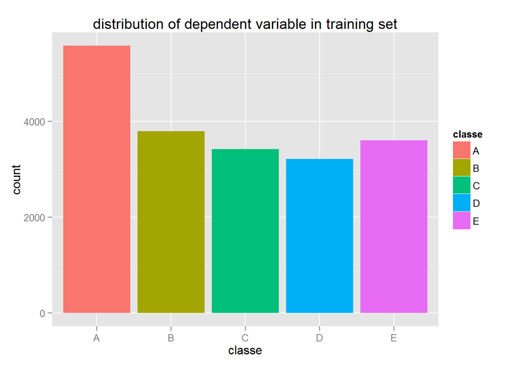

```r
library(ggplot2)

#read file from local directory
motion <- read.csv("pml-training.csv")

##results of the summary function are worth reviewing but is too large to print in this report.
## summary(traindf)
##sd <- summarize_each(motion, funs(sd))

#plot distribution of classe variable
class <- ggplot(motion, aes(x=classe, fill=classe))+
        geom_histogram() +
        ggtitle("distribution of dependent variable in training set")
class
```

### Clean data, create test and training sets

```r
library(dplyr)
library(caret)

## dimensions of training data set
dim(motion)
```

```
## [1] 19622   160
```

```r
## remove columns for time and other variable unrelated to the quality of the
## exercise
motion <- select(motion, -(1:7))

## remove near zero variance columns (removes over 60 columns)
nzv_cols <- nearZeroVar(motion)
if (length(nzv_cols) > 0) motion <- motion[, -nzv_cols]

## remove NAs - remove rows without dependent variable
motion <- filter(motion, !is.na(classe))

## remove columns with NAs
motion <- motion[, colSums(is.na(motion)) == 0]

## convert to factor
motion <- mutate(motion, classe = as.factor(classe))

## dimensions of training data set after cleaning
dim(motion)
```

```
## [1] 19622    53
```

```r
# create training and test sets
inTrain <- createDataPartition(y = motion$classe, p = 0.7, list = FALSE)
training <- motion[inTrain, ]
dim(training)
```

```
## [1] 13737    53
```

```r
testing <- motion[-inTrain, ]
dim(testing)
```

```
## [1] 5885   53
```

### Create a random forest model

#### Sample error and estimating the error with cross-validation

I used five-fold cross validation to tune the random forest model. It gave me essentially the same results as using the bootstrap validation that I used on an earlier version of the model.

#### good results for Random Forest - high accuracy when validated against test set

```r
library(caret)

# create RANDOM FOREST model and print results
rfMod <- train(training$classe~.,
               data=training,
               method="rf",
              trControl=trainControl(method="cv",number=5),
             verbose=FALSE)

rfMod
```

```
## Random Forest
##
## 13737 samples
##    52 predictor
##     5 classes: 'A', 'B', 'C', 'D', 'E'
##
## No pre-processing
## Resampling: Cross-Validated (5 fold)
## Summary of sample sizes: 10991, 10988, 10990, 10988, 10991
## Resampling results across tuning parameters:
##
##   mtry  Accuracy   Kappa      Accuracy SD  Kappa SD
##    2    0.9909733  0.9885805  0.002487075  0.003146797
##   27    0.9905367  0.9880292  0.002372356  0.003001872
##   52    0.9824564  0.9778058  0.004490421  0.005680035
##
## Accuracy was used to select the optimal model using  the largest value.
## The final value used for the model was mtry = 2.
```

```r
#save model object to working directory when needed to save computation time
#saveRDS(rfMod, "RandomTreesModel20NOV15.rds")
#to read saved model, use use rfMod <- readRDS("RandomTreesModel15NOV15.rds")

#create confusion matrix to assess accuracy
pred <- (predict(rfMod, testing))
confusionMatrix(pred, testing$classe)
```

```
## Confusion Matrix and Statistics
##
##           Reference
## Prediction    A    B    C    D    E
##          A 1674   10    0    0    0
##          B    0 1127    2    0    0
##          C    0    2 1024   19    0
##          D    0    0    0  944    0
##          E    0    0    0    1 1082
##
## Overall Statistics
##
##                Accuracy : 0.9942
##                  95% CI : (0.9919, 0.996)
##     No Information Rate : 0.2845
##     P-Value [Acc > NIR] : < 2.2e-16
##
##                   Kappa : 0.9927
##  Mcnemar's Test P-Value : NA
##
## Statistics by Class:
##
##                      Class: A Class: B Class: C Class: D Class: E
## Sensitivity            1.0000   0.9895   0.9981   0.9793   1.0000
## Specificity            0.9976   0.9996   0.9957   1.0000   0.9998
## Pos Pred Value         0.9941   0.9982   0.9799   1.0000   0.9991
## Neg Pred Value         1.0000   0.9975   0.9996   0.9960   1.0000
## Prevalence             0.2845   0.1935   0.1743   0.1638   0.1839
## Detection Rate         0.2845   0.1915   0.1740   0.1604   0.1839
## Detection Prevalence   0.2862   0.1918   0.1776   0.1604   0.1840
## Balanced Accuracy      0.9988   0.9945   0.9969   0.9896   0.9999
```

### PART 2 - TEST MODEL AGAINST GRADED TEST SET AND SUBMIT TO COURSERA

### Clean final testing set before running through random forest model and submitting results for grading

```r
library(dplyr)
library(caret)

## read test file from local directory
tester <- read.csv("pml-testing.csv")

## dimensions of testing data set
dim(tester)
```

```
## [1]  20 160
```

```r
## remove columns for time and other variable unrelated to the quality of the
## exercise
tester <- select(tester, -(1:7))

## remove near zero variance columns (removes over 60 columns)
nzv_cols <- nearZeroVar(tester)
if (length(nzv_cols) > 0) tester <- tester[, -nzv_cols]

## remove columns with NAs
tester <- tester[, colSums(is.na(motion)) == 0]

## dimensions of training data set after cleaning
dim(tester)
```

```
## [1] 20 53
```

```r
## run against random forest model to predict dpendent variable
answers <- predict(rfMod, tester)

## function provided for assignment pml_write_files = function(x){ n =
## length(x) for(i in 1:n){ filename = paste0('problem_id_',i,'.txt')
## write.table(x[i],file=filename,quote=FALSE,row.names=FALSE,col.names=FALSE)
## } }

# pml_write_files(answers)
```

#### Thank you for reviewing my project. I learned a lot and am glad I took the class.